# 09_ovnis_Presentacion

Aitor Garcia Manterola

02 de junio de 2018

## Reto exploración avistamientos de OVNIs

Vamos a explorar un conjunto de datos sobre avistamientos de OVNIs, disponible en este repositorio en `retos/dat/ufos.csv`. Cópialo a una carpeta `dat/` dentro de la carpeta con la solución a este reto. El resultado debes presentarlo en un notebook de jupyter o Rmarkdown. Explora los datos contestando a las siguientes preguntas:

- ¿Qué países aparecen en el dataset? ¿Cuál tiene mayor número de avistamientos?
- ¿Cuáles son las 10 formas de OVNI avistadas más frecuentes (y cuál es esa frecuencia)? Con forma me refiero a: luz, óvalo, triángulo, …
- ¿Cómo se distribuye la duraciÃ³n de los avistamientos? En formato texto puedes sacar valores como mínimo, máximo, cuartiles, … y en formato gráfico pintar un histograma
- ¿Cómo se distribuye el tiempo pasado entre el momento del avistamiento (datetime) y la fecha de publicación (date_posted)? (Ídem sobre cómo expresar la distribución entre formato texto y gráfico)
- ¿Se observa un crecimiento o decrecimiento de los avistamientos a lo largo del tiempo?

# ¿Qué países aparecen en el dataset? ¿Cuál tiene mayor número de avistamientos?

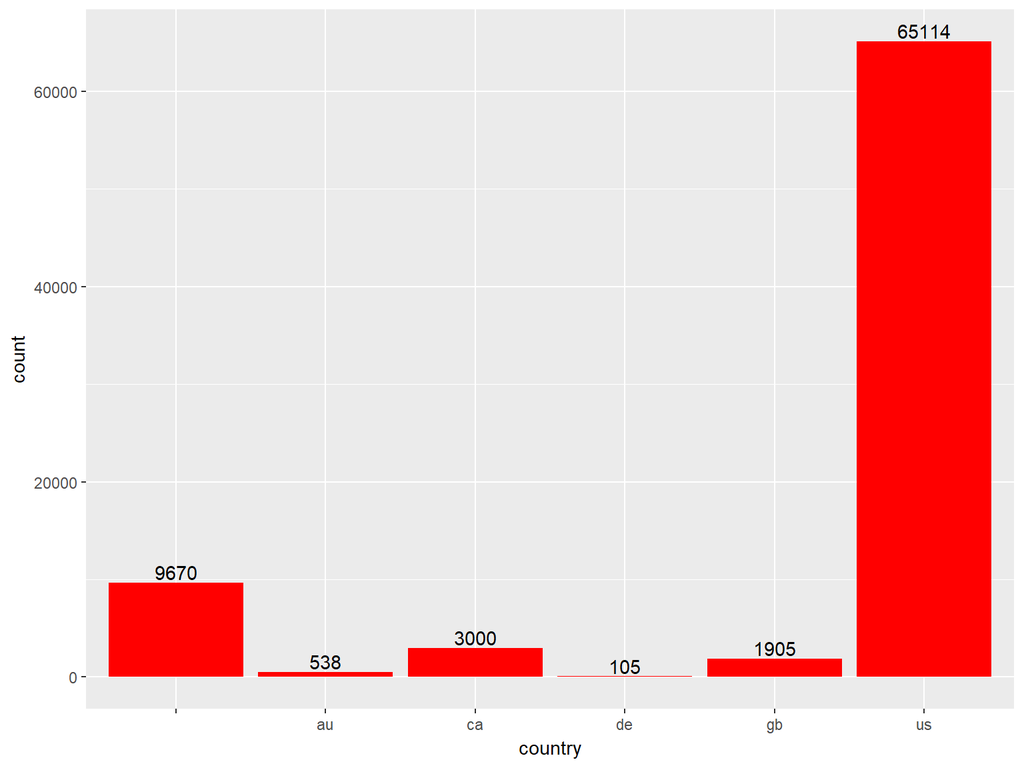

# ¿Cuáles son las 10 formas (luz, óvalo, triángulo, …) de OVNI avistadas más frecuentes (y cuál es esa frecuencia)?

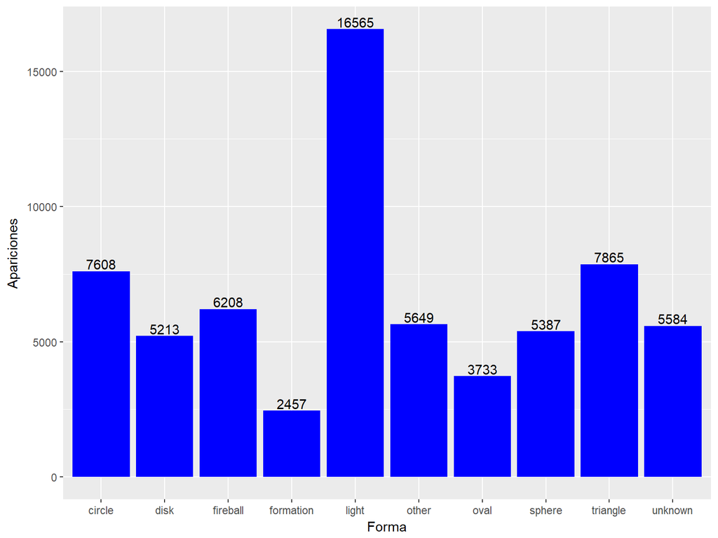

[figure not shown]

[interactive chart not shown]

# ¿Cómo se distribuye la duración de los avistamientos?

[figure not shown]

# Cómo se distribuye el tiempo pasado entre el momento del avistamiento (datetime) y la fecha de publicación (date_posted)?

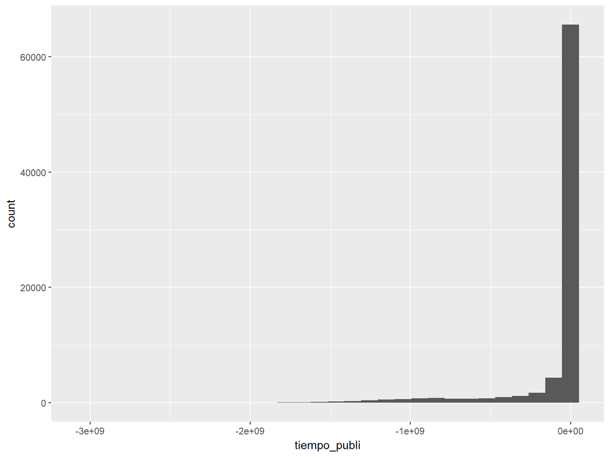

# ¿Se observa un crecimiento o decrecimiento de los avistamientos a lo largo del tiempo?

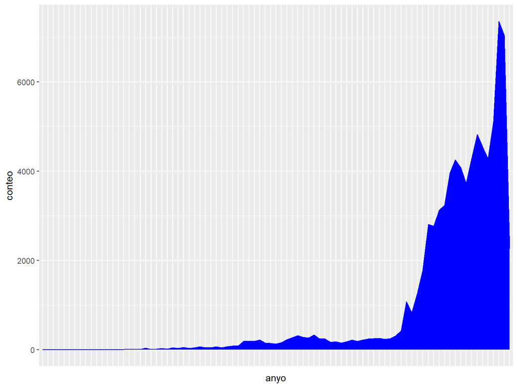